# False Sign Rate Illustration

# FSR Example

This is an example of how the false sign rate and the false discovery rate can be very different when a large proportion of the nulls are false.

In this example, we assume that the true $\beta_j$ ($j=1,\dots,n$) are normally distributed, $\beta_j \sim N(0,1)$. So no $\beta_j$ is exactly 0, and all the null hypotheses $H_j: \beta_j=0$ are false. Since all the nulls are false, no discovery is a false discovery, and the ``true" FDR is always 0, whatever threshold is used.

```r
#opts_chunk$set(fig.path='figure/lfsr/')
set.seed(100)
library(ashr)
library(qvalue)
n = 10000
beta = rnorm(n)
sebetahat = 1
betahat = beta + rnorm(n,0,sebetahat)

z = betahat/sebetahat
p = pchisq(z^2, df=1,lower.tail=FALSE)
z.ash = ash(z,1,method="fdr")
z.qvalue = qvalue(p)
```

In this example all the nulls are false, so the actual proportion of true nulls, $\pi_0$, is equal to 0. However, the estimated value of $\pi_0$ can be very different from zero. From qvalue we get an estimated $\pi_0$ of 0.6896916. This makes sense when you look at the distribution of p values, and recall that qvalue makes the assumption that all $p$ values near 1 are null (see histogram below). In contrast, ash produces a much smaller estimate of $\pi_0$ ($\pi0=$ 0.3617533), because it allows that many $p$ values near 1 may actually arise even when $\beta_j \neq 0$. Of course, in this case both qvalue and ash provide “conservative” estimates of $\pi_0$, but the qvalue estimate is much more conservative.

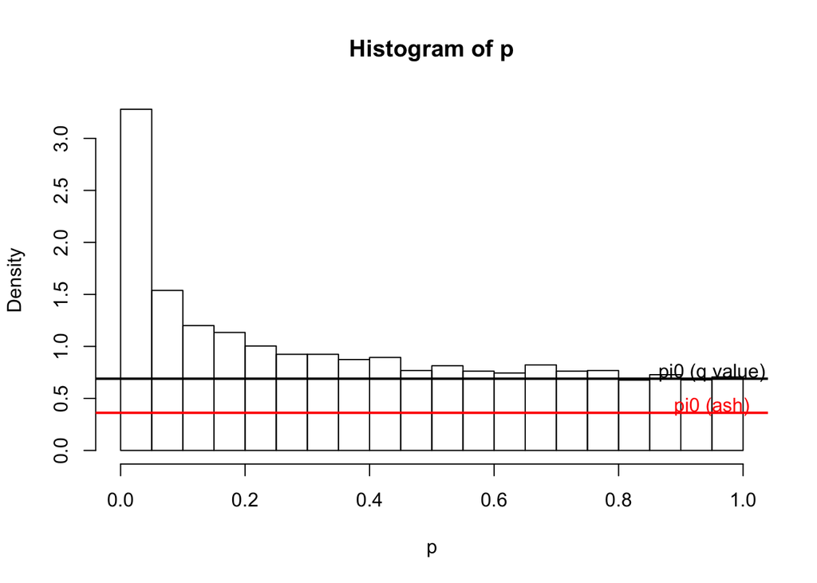

```r
  hist(p,prob=TRUE)
  abline(h=z.qvalue$pi0,lwd=2)
  text(0.95, z.qvalue$pi0+0.06, "pi0 (q value)")
  abline(h=get_pi0(z.ash),col=2,lwd=2)
  text(0.95, get_pi0(z.ash)+0.06,"pi0 (ash)",col=2)
```

Because of its very conservative estimate of $\pi_0$, qvalue also provides much more conservative estimates of the FDR. For example, at a $p$ value threshold of 0.05, qvalue estimates the FDR to be 0.2100752 whereas ash estimates the FDR as 0.1121565. Of course, the true value of the FDR is zero, so both are conservative.

In this example, at a $p$ value threshold of 0.05, $\ash$ estimates the local false sign rate (lfsr) to be 0.2414361 and the tail false sign rate (FSR) to be 0.1305038. The actual FSR at that threshold is 0.0457317. (The conservative estimates from $\ash$ are likely partly due to our deliberate use of a penalty term to provide conservative estimates of $\pi_0$.)